# Affiliated Package: Astroquery

[Astroquery](http://www.astropy.org/astroquery/) is an Astropy-affiliated package that contains a collection of tools to access online Astronomical data. To install it, do:

```
pip install astroquery
```

The following modules have been completed using a common API:

- SIMBAD Queries (`astroquery.simbad`)
- VizieR Queries (`astroquery.vizier`)
- IRSA Dust Extinction Service Queries (`astroquery.irsa_dust`)
- NED Queries (`astroquery.ned`)
- Splatalogue Queries (`astroquery.splatalogue`)
- IRSA Image Server program interface (IBE) Queries (`astroquery.ibe`)
- IRSA Queries (`astroquery.irsa`)
- UKIDSS Queries (`astroquery.ukidss`)
- MAGPIS Queries (`astroquery.magpis`)
- NRAO Queries (`astroquery.nrao`)
- Besancon Queries (`astroquery.besancon`)
- NIST Queries (`astroquery.nist`)
- NVAS Queries (`astroquery.nvas`)
- GAMA Queries (`astroquery.gama`)
- ESO Queries (`astroquery.eso`)
- xMatch Queries (`astroquery.xmatch`)
- Atomic Line List (`astroquery.atomic`)
- ALMA Queries (`astroquery.alma`)
- Skyview Queries (`astroquery.skyview`)
- NASA ADS Queries (`astroquery.nasa_ads`)
- HEASARC Queries (`astroquery.heasarc`)
- LCOGT Queries (`astroquery.lcogt`)

These others are functional, but do not follow a common & consistent API:

- Fermi Queries (`astroquery.fermi`)
- SDSS Queries (`astroquery.sdss`)
- ALFALFA Queries (`astroquery.alfalfa`)
- Spitzer Heritage Archive (`astroquery.sha`)
- LAMDA Queries (`astroquery.lamda`)
- OGLE Queries (`astroquery.ogle`)
- Open Exoplanet Catalogue(`astroquery.open_exoplanet_catalogue`)
- CosmoSim Queries (`astroquery.cosmosim`)

## SIMBAD

As an example, let's run a SIMBAD query:

```python
from astropy import units as u
from astroquery.simbad import Simbad
```

```python
r = Simbad.query_region('m42', radius=3. * u.arcmin)
```

```python
r.colnames
```

```
['MAIN_ID',
 'RA',
 'DEC',
 'RA_PREC',
 'DEC_PREC',
 'COO_ERR_MAJA',
 'COO_ERR_MINA',
 'COO_ERR_ANGLE',
 'COO_QUAL',
 'COO_WAVELENGTH',
 'COO_BIBCODE']
```

```python
r
```

<Table masked=True length=2266>

| MAIN_ID object | RA "h:m:s" str13 | DEC "d:m:s" str13 | RA_PREC int16 | DEC_PREC int16 | COO_ERR_MAJA mas float32 | COO_ERR_MINA mas float32 | COO_ERR_ANGLE deg int16 | COO_QUAL str1 | COO_WAVELENGTH str1 | COO_BIBCODE object |
| --- | --- | --- | --- | --- | --- | --- | --- | --- | --- | --- |
| NAME ORI REGION | 05 35 17.30 | -05 23 28.0 | 6 | 6 | -- | -- | 0 | D | O |  |
| M 42 | 05 35 17.3 | -05 23 28 | 5 | 5 | 7500.000 | 7500.000 | 90 | D |  | 1981MNRAS.194..693L |
| [OW94] 172-237 | 05 35 17.20 | -05 23 26.8 | 6 | 6 | -- | -- | 0 | D |  | 1999AJ....117.1375S |
| [OW94] 172-327 | 05 35 17.20 | -05 23 26.8 | 6 | 6 | -- | -- | 0 | D |  | 1996AJ....111..846O |
| DOH 7 175-328 | 05 35 17.5 | -05 23 28 | 5 | 5 | -- | -- | 0 | D |  | 2004AJ....127.3456D |
| MAX 126 | 05 35 17.11 | -05 23 29.3 | 6 | 6 | -- | -- | 0 | D | I | 2005AJ....129.1534R |
| DOH 7 171-327 | 05 35 17.1 | -05 23 27 | 5 | 5 | -- | -- | 0 | D |  | 2004AJ....127.3456D |
| MAX 125 | 05 35 17.11 | -05 23 26.6 | 6 | 6 | -- | -- | 0 | D | I | 2005AJ....129.1534R |
| [OW94] 171-326 | 05 35 17.1 | -05 23 26 | 5 | 5 | -- | -- | 0 | D |  | 2004AJ....127.3456D |
| ... | ... | ... | ... | ... | ... | ... | ... | ... | ... | ... |
| TPSC 8 | 05 35 18.9148 | -05 20 30.941 | 8 | 8 | 300.000 | 300.000 | 90 | C | M | 2011ApJ...733...50M |
| [YKS96] 8 | 05 35 11.0 | -05 26 00 | 5 | 5 | 3000.000 | 3000.000 | 90 | D |  |  |
| 2MASS J05350705-0525005 | 05 35 07.05 | -05 25 00.5 | 6 | 6 | 80.000 | 80.000 | 90 | B | I | 2003yCat.2246....0C |
| [LB2000] 19 | 05 35 13.0 | -05 20 41 | 5 | 5 | -- | -- | 0 | D |  | 2000MNRAS.315...11L |
| 2MASS J05351814-0520295 | 05 35 18.142 | -05 20 29.52 | 7 | 7 | 170.000 | 160.000 | 96 | B | I | 2003yCat.2246....0C |
| COUP J053514.1-052620 | 05 35 14.191 | -05 26 20.83 | 7 | 7 | -- | -- | 0 | D |  | 2005ApJS..160..319G |
| JW 377 | 05 35 12.272 | -05 20 45.24 | 7 | 7 | 60.000 | 60.000 | 90 | B | I | 2003yCat.2246....0C |
| MLLA 919 | 05 35 12.59 | -05 20 42.9 | 6 | 6 | 150.000 | 150.000 | 90 | C | O | 2009A&A...502..883R |
| [NW2007] OrionAN-0535146-52623 | 05 35 14.6 | -05 26 23 | 5 | 5 | -- | -- | 0 | E | m | 2007MNRAS.374.1413N |
| MLLA 945 | 05 35 19.69 | -05 20 31.6 | 6 | 6 | -- | -- | 0 | C | O | 2009ApJS..183..261D |

## SDSS

In the following example we are looking for the SDSS photometry for a small subset of objects from the [WTS survey](http://www.epj-conferences.org/articles/epjconf/abs/2013/08/epjconf_hpcs2012_01001/epjconf_hpcs2012_01001.html) and aim to have get a table that contains both the UKIRT JHK and SDSS griz values.

```python
from astropy.table import Table, join
from astropy.coordinates import SkyCoord

from astroquery.sdss import SDSS
```

```python
input_objects = Table.read('data/WTS_sources.txt', format='ascii')
input_objects
```

<Table length=10>

| obj_id str11 | RA float64 | DEC float64 | J float64 | J_err float64 | H float64 | H_err float64 | K float64 | K_err float64 |
| --- | --- | --- | --- | --- | --- | --- | --- | --- |
| 03a_1_02152 | 0.93857383728 | 0.683256566525 | 17.9808491201 | 0.0207520462573 | 17.5430990695 | 0.0326838642359 | 17.4166552607 | 0.0527142696083 |
| 03a_1_02153 | 0.938583731651 | 0.683691978455 | 18.0648678789 | 0.0217652115971 | 17.5391981719 | 0.0325625613332 | 16.9371263064 | 0.0348142385483 |
| 03a_1_02156 | 0.938584625721 | 0.681995213032 | 17.9732502974 | 0.0206765681505 | 17.2334487958 | 0.0252559948713 | 16.4199636109 | 0.0226280763745 |
| 03a_1_02158 | 0.938563227654 | 0.683355808258 | 20.7172761945 | 0.140657648444 | inf | nan | inf | nan |
| 03a_1_02160 | 0.938555300236 | 0.681509137154 | 21.2490735279 | 0.224075511098 | inf | nan | inf | nan |
| 03a_1_02162 | 0.93855214119 | 0.680877268314 | 19.4966230462 | 0.0548128969967 | 18.8312029848 | 0.101374149323 | 18.3430683514 | 0.120554670691 |
| 03a_1_02166 | 0.93855702877 | 0.68312805891 | 19.9568598967 | 0.0768099501729 | 18.9387728594 | 0.111240930855 | 18.7191155354 | 0.168692871928 |
| 03a_1_02170 | 0.938580811024 | 0.681022107601 | 18.0283851513 | 0.021364480257 | 17.939717686 | 0.0460969209671 | 17.5551734009 | 0.059726126492 |
| 03a_1_02173 | 0.938569068909 | 0.682113647461 | 20.3965879564 | 0.10850790143 | inf | nan | 18.783836708 | 0.179137885571 |
| 03a_1_02177 | 0.938546717167 | 0.683004200459 | 19.8941016896 | 0.0732068419456 | 19.7680823892 | 0.235651060939 | 18.8423313547 | 0.188655138016 |

```python
coords = SkyCoord(input_objects['RA'], input_objects['DEC'],
                         unit=u.rad)
photoobj_fields = ['ra', 'dec',
                   'psfMag_g', 'psfMagErr_g',
                   'psfMag_r', 'psfMagErr_r',
                   'psfMag_i', 'psfMagErr_i',
                   'psfMag_z', 'psfMagErr_z']
```

```python
sdss_match = SDSS.query_crossid(coords, photoobj_fields=photoobj_fields,
                                obj_names=input_objects['obj_id'])
sdss_match
```

<Table length=10>

| obj_id bytes11 | objID int64 | ra float64 | dec float64 | psfMag_g float64 | psfMagErr_g float64 | psfMag_r float64 | psfMagErr_r float64 | psfMag_i float64 | psfMagErr_i float64 | psfMag_z float64 | psfMagErr_z float64 | obj_id1 int64 | type bytes6 |
| --- | --- | --- | --- | --- | --- | --- | --- | --- | --- | --- | --- | --- | --- |
| 03a_1_02152 | 1237661083200914337 | 53.7763475699 | 39.1477052698 | 20.22518 | 0.01718431 | 19.49991 | 0.01400625 | 19.16798 | 0.01363996 | 19.03462 | 0.03476865 | 1237661083200914337 | STAR |
| 03a_1_02153 | 1237661055283431404 | 53.7768624524 | 39.1726384998 | 22.04197 | 0.05918801 | 21.15874 | 0.04040684 | 20.59106 | 0.03516813 | 20.27402 | 0.09355691 | 1237661055283431404 | GALAXY |
| 03a_1_02156 | 1237661083200915425 | 53.7769543058 | 39.0754423012 | 23.30584 | 0.151412 | 21.49913 | 0.0494917 | 20.60164 | 0.03441215 | 20.05799 | 0.06879599 | 1237661083200915425 | GALAXY |
| 03a_1_02158 | 1237661083200915854 | 53.7757701984 | 39.1533737737 | 25.1751 | 0.3952022 | 23.5405 | 0.2696459 | 22.59764 | 0.1840275 | 21.6267 | 0.2378835 | 1237661083200915854 | STAR |
| 03a_1_02160 | 1237661083200916007 | 53.7752574121 | 39.0476122895 | 24.43489 | 0.3323026 | 22.84913 | 0.1516651 | 22.57256 | 0.1758984 | 22.03286 | 0.3059358 | 1237661083200916007 | GALAXY |
| 03a_1_02162 | 1237661083200916297 | 53.7751266746 | 39.0114259738 | 25.15113 | 0.3950934 | 24.24655 | 0.4008771 | 22.04818 | 0.1129966 | 20.98827 | 0.1450246 | 1237661083200916297 | STAR |
| 03a_1_02166 | 1237661083200915086 | 53.7753637753 | 39.1403334011 | 22.954 | 0.1135179 | 22.05993 | 0.07951325 | 21.77163 | 0.09029607 | 21.0596 | 1.005257 | 1237661083200915086 | GALAXY |
| 03a_1_02170 | 1237661083200915135 | 53.7767053408 | 39.0196976885 | 21.51745 | 0.03730422 | 20.82818 | 0.02983859 | 20.57401 | 0.03423917 | 20.35621 | 0.08718228 | 1237661083200915135 | GALAXY |
| 03a_1_02173 | 1237661083200913727 | 53.7760557864 | 39.0822289325 | 24.25553 | 0.7155227 | 23.26116 | 0.2138949 | 22.28827 | 0.1384539 | 22.57337 | 0.4684004 | 1237661083200913727 | GALAXY |
| 03a_1_02177 | 1237661083200915095 | 53.7747721614 | 39.1332356787 | 21.73889 | 0.04302375 | 21.12062 | 0.0371522 | 20.86909 | 0.04221161 | 20.69124 | 0.1134799 | 1237661083200915095 | STAR |

```python
result = join(input_objects, sdss_match, keys='obj_id', join_type='left')
result
```

<Table length=10>

| obj_id str14 | RA float64 | DEC float64 | J float64 | J_err float64 | H float64 | H_err float64 | K float64 | K_err float64 | objID int64 | ra float64 | dec float64 | psfMag_g float64 | psfMagErr_g float64 | psfMag_r float64 | psfMagErr_r float64 | psfMag_i float64 | psfMagErr_i float64 | psfMag_z float64 | psfMagErr_z float64 | obj_id1 int64 | type bytes6 |
| --- | --- | --- | --- | --- | --- | --- | --- | --- | --- | --- | --- | --- | --- | --- | --- | --- | --- | --- | --- | --- | --- |
| 03a_1_02152 | 0.93857383728 | 0.683256566525 | 17.9808491201 | 0.0207520462573 | 17.5430990695 | 0.0326838642359 | 17.4166552607 | 0.0527142696083 | 1237661083200914337 | 53.7763475699 | 39.1477052698 | 20.22518 | 0.01718431 | 19.49991 | 0.01400625 | 19.16798 | 0.01363996 | 19.03462 | 0.03476865 | 1237661083200914337 | STAR |
| 03a_1_02153 | 0.938583731651 | 0.683691978455 | 18.0648678789 | 0.0217652115971 | 17.5391981719 | 0.0325625613332 | 16.9371263064 | 0.0348142385483 | 1237661055283431404 | 53.7768624524 | 39.1726384998 | 22.04197 | 0.05918801 | 21.15874 | 0.04040684 | 20.59106 | 0.03516813 | 20.27402 | 0.09355691 | 1237661055283431404 | GALAXY |
| 03a_1_02156 | 0.938584625721 | 0.681995213032 | 17.9732502974 | 0.0206765681505 | 17.2334487958 | 0.0252559948713 | 16.4199636109 | 0.0226280763745 | 1237661083200915425 | 53.7769543058 | 39.0754423012 | 23.30584 | 0.151412 | 21.49913 | 0.0494917 | 20.60164 | 0.03441215 | 20.05799 | 0.06879599 | 1237661083200915425 | GALAXY |
| 03a_1_02158 | 0.938563227654 | 0.683355808258 | 20.7172761945 | 0.140657648444 | inf | nan | inf | nan | 1237661083200915854 | 53.7757701984 | 39.1533737737 | 25.1751 | 0.3952022 | 23.5405 | 0.2696459 | 22.59764 | 0.1840275 | 21.6267 | 0.2378835 | 1237661083200915854 | STAR |
| 03a_1_02160 | 0.938555300236 | 0.681509137154 | 21.2490735279 | 0.224075511098 | inf | nan | inf | nan | 1237661083200916007 | 53.7752574121 | 39.0476122895 | 24.43489 | 0.3323026 | 22.84913 | 0.1516651 | 22.57256 | 0.1758984 | 22.03286 | 0.3059358 | 1237661083200916007 | GALAXY |
| 03a_1_02162 | 0.93855214119 | 0.680877268314 | 19.4966230462 | 0.0548128969967 | 18.8312029848 | 0.101374149323 | 18.3430683514 | 0.120554670691 | 1237661083200916297 | 53.7751266746 | 39.0114259738 | 25.15113 | 0.3950934 | 24.24655 | 0.4008771 | 22.04818 | 0.1129966 | 20.98827 | 0.1450246 | 1237661083200916297 | STAR |
| 03a_1_02166 | 0.93855702877 | 0.68312805891 | 19.9568598967 | 0.0768099501729 | 18.9387728594 | 0.111240930855 | 18.7191155354 | 0.168692871928 | 1237661083200915086 | 53.7753637753 | 39.1403334011 | 22.954 | 0.1135179 | 22.05993 | 0.07951325 | 21.77163 | 0.09029607 | 21.0596 | 1.005257 | 1237661083200915086 | GALAXY |
| 03a_1_02170 | 0.938580811024 | 0.681022107601 | 18.0283851513 | 0.021364480257 | 17.939717686 | 0.0460969209671 | 17.5551734009 | 0.059726126492 | 1237661083200915135 | 53.7767053408 | 39.0196976885 | 21.51745 | 0.03730422 | 20.82818 | 0.02983859 | 20.57401 | 0.03423917 | 20.35621 | 0.08718228 | 1237661083200915135 | GALAXY |
| 03a_1_02173 | 0.938569068909 | 0.682113647461 | 20.3965879564 | 0.10850790143 | inf | nan | 18.783836708 | 0.179137885571 | 1237661083200913727 | 53.7760557864 | 39.0822289325 | 24.25553 | 0.7155227 | 23.26116 | 0.2138949 | 22.28827 | 0.1384539 | 22.57337 | 0.4684004 | 1237661083200913727 | GALAXY |
| 03a_1_02177 | 0.938546717167 | 0.683004200459 | 19.8941016896 | 0.0732068419456 | 19.7680823892 | 0.235651060939 | 18.8423313547 | 0.188655138016 | 1237661083200915095 | 53.7747721614 | 39.1332356787 | 21.73889 | 0.04302375 | 21.12062 | 0.0371522 | 20.86909 | 0.04221161 | 20.69124 | 0.1134799 | 1237661083200915095 | STAR |

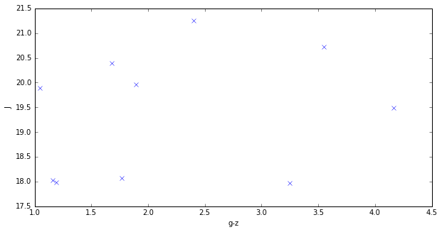

```python
import matplotlib.pylab as plt
%matplotlib inline

plt.rc('figure', figsize=(10, 5))
plt.ylabel('J')
plt.xlabel('g-z')
plt.plot(result['psfMag_g']-result['psfMag_z'], result['J'], 'x')
```

## Practical Exercise

Go to the documentation and try out a query interface for a service that might be relevant to you!